# Reproducible Research: Peer Assessment 1

## Loading and preprocessing the data

```r
# Install lattice library
install.packages("https://cran.rstudio.com/bin/macosx/mavericks/contrib/3.3/lattice_0.20-35.tgz",repos=NULL,lib=.libPaths()[1])

library(lattice)

# Set the working directory
setwd("~/Desktop/R Files/RepData_PeerAssessment1")

# Read data set and convert data column to Date format
activity <- read.csv("activity.csv")
```

## What is mean total number of steps taken per day?

### 1. Make a histogram of the total number of steps taken each day

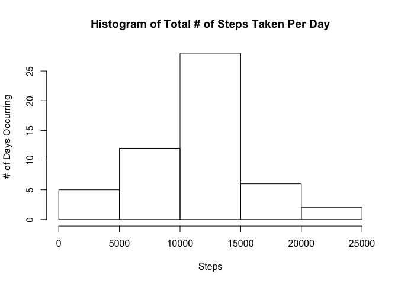

```r
# Calculate the total number of steps taken each day
StepsPerDay <- aggregate(activity$steps~activity$date,activity,sum,na.rm=TRUE)
names(StepsPerDay) <- c("date","total_steps")

# Plot a histogram of total number of steps taken each day
hist(StepsPerDay$total_steps,main="Histogram of Total # of Steps Taken Per Day", xlab="Steps", ylab="# of Days Occurring")
```

### 2. Calculate and report the mean and median total number of steps taken each day

```r
# Calculate the mean and median values for total number of steps taken per day.  Report the data in markdown.

mean <- mean(StepsPerDay$total_steps)

median <- median(StepsPerDay$total_steps)
```

- The mean number of steps taken per day is 10766.2 and the median is 10765.0.

## What is the average daily activity pattern?

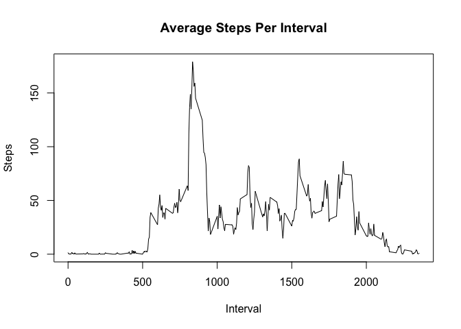

```r
# Make a time series plot (i.e. type = "l") of the 5-minute interval (x-axis) and the average number of steps taken, averaged across all days (y-axis)

SummaryPerInterval <- aggregate(activity$steps~activity$interval,activity,sum,na.rm=TRUE)
names(SummaryPerInterval) <- c("Interval","TotalSteps")
totaldays <- length(unique(activity$date))
SummaryPerInterval$AverageSteps <- SummaryPerInterval$TotalSteps/totaldays

with(SummaryPerInterval,plot(Interval,AverageSteps,type="l",main="Average Steps Per Interval",ylab="Steps",xlab="Interval"))
```

```r
# Which 5-minute interval, on average across all the days in the dataset, contains the maximum number of steps?

# Calculate the maximum average steps
maxStepsInterval <- subset(SummaryPerInterval,SummaryPerInterval$AverageSteps==max(SummaryPerInterval$AverageSteps), select=Interval)[[1]]
```

[output not shown]

## Imputing missing values

### 1. Calculate and report the total number of missing values in the dataset (i.e. the total number of rows with NAs)

```r
# Determine the number of missing values

NAvalues <- is.na(activity$steps)
numNAvalues <- length(NAvalues[NAvalues==TRUE])
```

- There are 2304 rows missing steps data (NA values) in the dataset.

### 2. Devise a strategy for filling in all of the missing values in the dataset. The strategy does not need to be sophisticated. For example, you could use the mean/median for that day, or the mean for that 5-minute interval, etc.

- Imputing the data will be done by using the mean for the corresponding 5-minute interval.

### 3. Create a new data set with imputed values

```r
# Impute data values for missing data using the mean for the 5-minute interval.  Use the table SummaryPerInterval as a lookup table for missing values.

activity_imputed <- activity

for (i in 1:length(activity$date)){
  if (is.na(activity_imputed[i,1])==TRUE){
    activity_imputed[i,1] <-   subset(SummaryPerInterval,SummaryPerInterval$Interval==activity_imputed[i,3], select=AverageSteps)[[1]]

  }
}
```

### 4. Make a histogram of the total number of steps taken each day and Calculate and report the mean and median total number of steps taken per day. Do these values differ from the estimates from the first part of the assignment? What is the impact of imputing missing data on the estimates of the total daily number of steps?

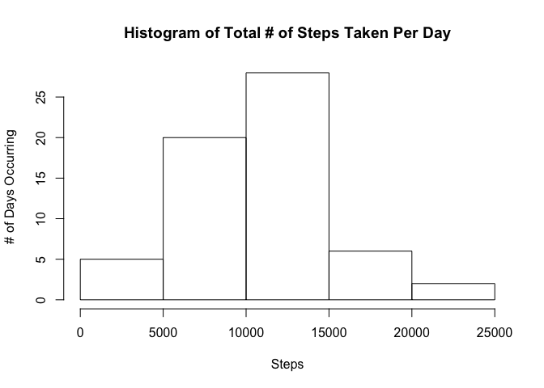

```r
# Calculate the total number of steps taken each day
StepsPerDay_imp <- aggregate(activity_imputed$steps~activity_imputed$date,activity_imputed,sum,na.rm=TRUE)
names(StepsPerDay_imp) <- c("date","total_steps")

# Plot a histogram of total number of steps taken each day
hist(StepsPerDay_imp$total_steps,main="Histogram of Total # of Steps Taken Per Day", xlab="Steps", ylab="# of Days Occurring")
```

```r
# Calculate the mean and median of the imputed data
mean_imp <- mean(StepsPerDay_imp$total_steps)

median_imp <- median(StepsPerDay_imp$total_steps)
```

- The mean number of steps taken per day with imputed data is 10581.0 and the median is 10395.0.
- Imputing the data has lowered the mean and median of the steps data and shifted the histogram.

## Are there differences in activity patterns between weekdays and weekends?

### 1. Create a new factor variable in the dataset with two levels – “weekday” and “weekend” indicating whether a given date is a weekday or weekend day.

```r
# Determine whether data record is for a weekend or weekday
activity_imputed$date <- as.Date(activity_imputed$date)

 activity_imputed$dayofweek <- weekdays(activity_imputed$date)
 for (i in 1:length(activity_imputed$date)){
     if (activity_imputed[i,4]=="Saturday" | activity_imputed[i,4]=="Sunday"){
        activity_imputed[i,5] <- "weekend"}
     else{
        activity_imputed[i,5] <- "weekday"
     }
  }

 # Rename data set columns for future use
 names(activity_imputed) <- c("steps","date","interval","dayofweek","partofweek")
```

### 2. Make a panel plot containing a time series plot (i.e. type = “l”) of the 5-minute interval (x-axis) and the average number of steps taken, averaged across all weekday days or weekend days (y-axis). The plot should look something like the following, which was created using simulated data:

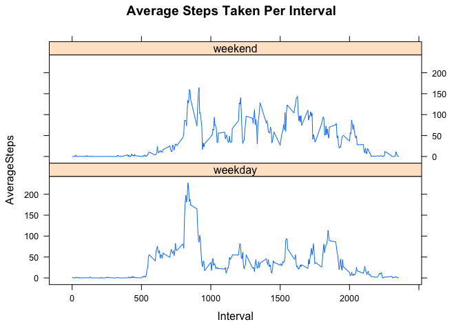

```r
# Create a subset of weekend data and find Average Steps per interval
weekend <- subset(activity_imputed,partofweek=="weekend",select=c(steps,date,interval))

WESummaryPerInterval <- aggregate(weekend$steps~weekend$interval,weekend,sum,na.rm=TRUE)
names(WESummaryPerInterval) <- c("Interval","TotalSteps")
totaldays <- length(unique(weekend$date))
WESummaryPerInterval$AverageSteps <- WESummaryPerInterval$TotalSteps/totaldays
WESummaryPerInterval$WeekPart <- "weekend"

# Create a subset of weekday data and find Average Steps per interval
weekday <-subset(activity_imputed, partofweek=="weekday",select=c(steps,date,interval))

WDSummaryPerInterval <- aggregate(weekday$steps~weekday$interval,weekday,sum,na.rm=TRUE)
names(WDSummaryPerInterval) <- c("Interval","TotalSteps")
totaldays <- length(unique(weekday$date))
WDSummaryPerInterval$AverageSteps <- WDSummaryPerInterval$TotalSteps/totaldays
WDSummaryPerInterval$WeekPart <- "weekday"

# Combind weekend and weekday data
days <- rbind(WESummaryPerInterval,WDSummaryPerInterval)

days$WeekPart <- as.factor(days$WeekPart)

# Create plot of Average Steps Per Interval by Weekend and WeekDay
xyplot(AverageSteps ~ Interval | factor(WeekPart), data=days, type="l",layout=c(1,2),main="Average Steps Taken Per Interval")
```